# Reanalysis of mouse-rat comparative gene expression data towards batch effects

Maciej Bielecki

## Data preparation

The dataset is retrieved and loaded.

```r
#Functions for loading TSV files
tsv_df = function(fn) read.csv(fn, sep="\t", header=TRUE, check.names=FALSE)
tsv_matrix = function(fn) as.matrix(tsv_df(fn))

#Retrieve dataset remotely
mice_raw = tsv_matrix("https://www.ebi.ac.uk/biostudies/files/E-MTAB-6081/mouse_counts.txt")
rats_raw = tsv_matrix("https://www.ebi.ac.uk/biostudies/files/E-MTAB-6081/rat_counts.txt")

#Load metadata
metadata = rbind(   tsv_df("https://www.ebi.ac.uk/biostudies/files/E-MTAB-6081/mouse_design.txt"),
                    tsv_df("https://www.ebi.ac.uk/biostudies/files/E-MTAB-6081/rat_design.txt"))
#Get tissue, species and batch columns
metadata$species = c(rep("Mouse", 39), rep("Rat", 40))
colnames(metadata)[2] = "tissue"
metadata$batch = as.integer(gsub(".*_L00([0-9])_.*", "\\1", metadata$file, perl=TRUE)) - 1
```

```r
#Retrieve top 174 homologues provided by Söllner et al.
soellner_homologues = tsv_df("https://www.ncbi.nlm.nih.gov/pmc/articles/PMC5726313/bin/sdata2017185-s2.txt")
#Each *_homologues data frame will hold a 'src' column, to inform what database each pair comes from
soellner_homologues$src = "soellner"
#Trim and reorder columns
soellner_homologues = soellner_homologues[,c(7,2,3)]


#ENSEMBL Biomart handles
mmus_ensembl = useMart("ensembl", "mmusculus_gene_ensembl")
rnov_ensembl = useMart("ensembl", "rnorvegicus_gene_ensembl")


#ENSEMBL
ensembl_homologues = getBM(
    #For each mouse gene in ENSEMBL
        mart=mmus_ensembl,
    #which has a rat homologue,
        filters="with_rnorvegicus_homolog", values=TRUE,
    #get its and the homologue's ENSEMBL gene IDs
        attributes=c("ensembl_gene_id", "rnorvegicus_homolog_ensembl_gene")
    )
#Format the df
ensembl_homologues$src = "ensembl"
colnames(ensembl_homologues) = c("mouse_ensgid", "rat_ensgid", "src")
ensembl_homologues = ensembl_homologues[,c(3,1,2)]
#Homology in ENSEMBL is bilateral, so there's no need to retrieve mouse homologues of rat genes


#MGI
mgi_homologues = tsv_df("https://www.informatics.jax.org/downloads/reports/HOM_AllOrganism.rpt")[,1:6]
#The report contains genes of several species; restrict it to rat and mouse genes
mgi_rat = mgi_homologues[mgi_homologues[,2] == "rat",]
mgi_mouse = mgi_homologues[mgi_homologues[,2] == "mouse, laboratory",]

#Lookup table, used to retrieve the mouse homologue of each rat gene in the list
mgi_rat_to_mouse = match(mgi_rat[,1], mgi_mouse[,1])

#Construct new data frame: one column is rat gene Entrez IDs, other column is mouse gene MGI IDs
mgi_homologues = data.frame(src="mgi", rat_entrez = mgi_rat[,5], mouse_mgi = mgi_mouse[mgi_rat_to_mouse,6])

#Lookup tables, used to convert Entrez and MGI IDs to ENSEMBL gene IDs
mgi_to_ens = getBM(
    #For each mouse gene in ENSEMBL
        mart=mmus_ensembl,
    #which has an MGI cross-reference,
        filters="with_mgi", values=TRUE,
    #get its ENSEMBL and MGI gene IDs
        attributes=c("ensembl_gene_id", "mgi_id")
    )
entrez_to_ens = getBM(
    #For each rat gene in ENSEMBL
        mart=rnov_ensembl,
    #which has an Entrez cross-reference,
        filters="with_entrezgene", values=TRUE,
    #get its ENSEMBL and Entrez gene IDs
        attributes=c("ensembl_gene_id", "entrezgene_id")
    )

#Convert gene IDs to ENSEMBL ones
mgi_homologues$mouse_ensgid = mgi_to_ens[match(mgi_homologues$mouse_mgi, mgi_to_ens$mgi_id),1]
mgi_homologues$rat_ensgid = entrez_to_ens[match(mgi_homologues$rat_entrez, entrez_to_ens$entrezgene_id),1]

#Reorder columns, remove genes which failed lookup
mgi_homologues=na.omit(mgi_homologues[,c(1,4,5)])


#HGNC
hgnc_homologues = tsv_df("https://g-a8b222.dd271.03c0.data.globus.org/pub/databases/genenames/hgnc/tsv/hgnc_complete_set.txt")[,c(28,29)]
#Restrict dataset to human homologues which have both a rat and mouse homologue
hgnc_homologues = hgnc_homologues[hgnc_homologues$mgd_id != "" & hgnc_homologues$rgd_id != "",]

#Lookup tables, used to convert RGD IDs to ENSEMBL gene IDs
rgd_to_ens = getBM(
    #For each rat gene in ENSEMBL
        filters="with_rgd", values=TRUE,
    #which has an RGD cross-reference,
        mart=rnov_ensembl,
    #get its ENSEMBL and RGD gene IDs
        attributes=c("ensembl_gene_id", "rgd_id")
    )
#Prepend RGD IDs in `rgd_to_ens' with "RGD:", since HGNC's RGD IDs are formatted as such
rgd_to_ens$rgd_id = gsub("^", "RGD:", rgd_to_ens$rgd_id)

#Convert gene IDs
hgnc_homologues$mouse_ensgid = mgi_to_ens[match(hgnc_homologues$mgd_id, mgi_to_ens$mgi_id),1]
hgnc_homologues$rat_ensgid = rgd_to_ens[match(hgnc_homologues$rgd_id, rgd_to_ens$rgd_id),1]

#Format and sanitize the df
hgnc_homologues$src = "hgnc"
hgnc_homologues=na.omit(hgnc_homologues[,c(5,3,4)])


#Join records
homologues = rbind(soellner_homologues, ensembl_homologues, mgi_homologues, hgnc_homologues)
#Dedupe
homologues = homologues[!duplicated(homologues$mouse_ensgid) & !duplicated(homologues$rat_ensgid),]
#Restrict list only to genes present in dataset
in_dataset = homologues$mouse_ensgid %in% rownames(mice_raw) & homologues$rat_ensgid %in% rownames(rats_raw)
homologues = homologues[in_dataset,]
```

The homologue pairs are used to subset and concatenate the matrices. Genes which lack a homologue will not be included in the combined dataset.

```r
paired = cbind(mice_raw[homologues$mouse_ensgid,], rats_raw[homologues$rat_ensgid,])

#Helper function used in renaming samples
#fields - what metadata to include in the name, and in what order
sample_names = function(fields) sapply(apply(metadata[,fields], 1, paste, simplify=FALSE), paste, collapse="_")

#Rename the sample such that they contain species and tissue type
colnames(paired) = sample_names(c("species", "tissue"))
```

Before the reanalysis, the dataset needs to be filtered an normalized. For normalization, information about gene GC content is required, and so needs to be retrieved.

```r
#Filter out 30% of genes with the lowest overall expression
row_sums = apply(paired, 1, sum)
above_cutoff = row_sums > quantile(row_sums, probs = 0.3)
paired_f = paired[above_cutoff,]
homologues_f = homologues[above_cutoff,]

#Filter out mitochondrial genes
mouse_mito = getBM(
    #For every mouse gene in database
        filters="chromosome_name", values="MT",
    #to be mitochondrial,
        mart=mmus_ensembl,
    #get its ENSEMBL dene ID
        attributes="ensembl_gene_id"
    )[,1]
rat_mito =getBM(
    #Likewise for rat genes
        mart=rnov_ensembl,
        filters="chromosome_name", values="MT",
        attributes="ensembl_gene_id"
    )[,1]
non_mito = !( homologues_f$mouse_ensgid %in% mouse_mito | homologues_f$rat_ensgid %in%rat_mito )
paired_f = paired_f[non_mito,]
homologues_f = homologues_f[non_mito,]
#`paired_f' and `homologues_f' now hold the filtered genes


#GC content lookup
mouse_gc = getGeneLengthAndGCContent(homologues_f$mouse_ensgid, "mmus", "biomart")
rat_gc   = getGeneLengthAndGCContent(homologues_f$rat_ensgid,   "rno",  "biomart")
homologues_f$mouse_gc = mouse_gc[,"gc"]
homologues_f$rat_gc   = rat_gc[,"gc"]
#Remove genes whose GC content failed to lookup
gc_content_known = ( !is.na(homologues_f$mouse_gc) & !is.na(homologues_f$rat_gc) )
paired_f = paired_f[gc_content_known,]
homologues_f = homologues_f[gc_content_known,]


#Normalization
paired_fn = paired_f
paired_fn[,1:39]  = withinLaneNormalization(paired_f[,1:39],  homologues_f$mouse_gc, which="loess", round=TRUE)
paired_fn[,40:79] = withinLaneNormalization(paired_f[,40:79], homologues_f$rat_gc,   which="loess", round=TRUE)
#`paired_fn' is now the filtered and partially normalized dataset

col_sums    = apply(paired, 2, sum)
col_sums_fn = apply(paired_fn, 2, sum)
norm_factors = calcNormFactors(paired_fn, method="TMM")
col_sums_nn = col_sums

i = 1
while ( i < length(col_sums_fn) ){
    col_sums_nn[i] = col_sums[i] * norm_factors[i]
    i = i+1
}
mean_depth = mean(col_sums_nn)
prior = paired_fn
i = 1
while ( i < ncol(prior) ){
  prior[,i] = (paired_fn[,i]/col_sums_nn[i])*mean_depth
  i = i+1
}


#Log-transform
prior = log2(prior+1)
#`prior' is now the dataset after preprocessing, but before adjustment
```

Before running ComBat, let’s see how many genes there are in the dataset:

```r
gene_cnt = data.frame(
    start = c(  nrow(soellner_homologues),
                nrow(ensembl_homologues),
                nrow(mgi_homologues),
                nrow(hgnc_homologues),
                nrow(mice_raw),
                nrow(rats_raw)),
    dedupe = c( sum(homologues$src == "soellner"),
                sum(homologues$src == "ensembl"),
                sum(homologues$src == "mgi"),
                sum(homologues$src == "hgnc"),
                nrow(paired),
                nrow(paired)),
    filter = c( sum(homologues_f$src == "soellner"),
                sum(homologues_f$src == "ensembl"),
                sum(homologues_f$src == "mgi"),
                sum(homologues_f$src == "hgnc"),
                nrow(paired_f),
                nrow(paired_f))
)

gene_cnt$rate = ( gene_cnt$filter / gene_cnt$start ) * 100
gene_cnt$rate = sprintf("%.2f%%", gene_cnt$rate)

colnames(gene_cnt) = c("Initial gene count", "Merged and deduplicated", "Filtered", "Passthrough rate")
rownames(gene_cnt) = c("Söllner et al.'s list", "ENSEMBL", "MGI", "HGNC", "Mouse dataset", "Rat dataset")

kable(gene_cnt)
```

|  | Initial gene count | Merged and deduplicated | Filtered | Passthrough rate |
| --- | --- | --- | --- | --- |
| Söllner et al.’s list | 174 | 174 | 152 | 87.36% |
| ENSEMBL | 33667 | 17487 | 12236 | 36.34% |
| MGI | 21254 | 249 | 161 | 0.76% |
| HGNC | 17039 | 88 | 29 | 0.17% |
| Mouse dataset | 47531 | 17998 | 12578 | 26.46% |
| Rat dataset | 32662 | 17998 | 12578 | 38.51% |

## Batch effect adjustment

With the data fully preprocessed, ComBat is used to correct for batch effects.

```r
design = model.matrix(~1, data=metadata[,c("batch", "tissue", "species")])
after = ComBat(dat=prior, batch=metadata$batch, mod=design, par.prior=TRUE)
```

```
## Found 542 genes with uniform expression within a single batch (all zeros); these will not be adjusted for batch.
```

```
## Found7batches
```

```
## Adjusting for0covariate(s) or covariate level(s)
```

```
## Standardizing Data across genes
```

```
## Fitting L/S model and finding priors
```

```
## Finding parametric adjustments
```

```
## Adjusting the Data
```

## Assessment of clustering

Statistical tests are carried out to verify whether the dataset exhibits *intra*-over-*inter* clustering, both for the dataset prior to and after adjustment.

First, the data is converted to long format, and the tissue and species annotation of each sample are one-hot encoded.

```r
prior_df = as.data.frame.table(prior)
#Add columns for tissue and species
extra_cols = do.call(rbind, strsplit(as.character(prior_df$Var2), split="_", fixed=TRUE, useBytes=TRUE))
prior_df = cbind(prior_df, extra_cols)
#Format df
colnames(prior_df) = c("gene", "sample_name", "expr", "species", "tissue")

#Likewise for adjusted data
after_df = as.data.frame.table(after)
after_df = cbind(after_df, extra_cols)
colnames(after_df) = c("gene", "sample_name", "expr", "species", "tissue")

#One-hot encoding
extra_cols = data.frame(isMouse = as.numeric(prior_df$species == "Mouse"),
                        isRat =   as.numeric(prior_df$species == "Rat"))
for (tissue in unique(metadata$tissue)) {
    extra_cols = cbind(extra_cols, as.numeric(prior_df$tissue == tissue))
    colnames(extra_cols)[ncol(extra_cols)] = paste0("is", tissue)
}
prior_df = cbind(prior_df, extra_cols)
after_df = cbind(after_df, extra_cols)
```

With the data formatted properly, the model is fitted.

```r
prior_lm = lmer(
    #Dependent variable
        expr ~ 0 +
    #Predictors
        isMouse     + isRat        +
        isPancreas  + isLiver      + isStomach  + isDuodenum    + isJejunum  +
        isIleum     + isColon      + isKidney   + isQuadriceps  + isThymus   +
        isHeart     + isEsophagus  + isBrain    + isKidneys     + isUnknown  +
    #Blocking variable
        (1|gene),
    #Data source
        data=prior_df
    )

after_lm = lmer(
    #Dependent variable
        expr ~ 0 +
    #Predictors
        isMouse     + isRat        +
        isPancreas  + isLiver      + isStomach  + isDuodenum    + isJejunum  +
        isIleum     + isColon      + isKidney   + isQuadriceps  + isThymus   +
        isHeart     + isEsophagus  + isBrain    + isKidneys     + isUnknown  +
    #Blocking variable
        (1|gene),
    #Data source
        data=after_df
    )
```

Let’s inspect the model’s coefficients:

```r
kable(data.frame(   Before = summary(prior_lm)$coefficients[,1],
                    After =  summary(after_lm)$coefficients[,1]
    ), caption = "Model coefficients")
```

Model coefficients

|  | Before | After |
| --- | --- | --- |
| isMouse | 10.196464 | 9.826145 |
| isRat | 9.909292 | 9.556326 |
| isPancreas | -2.048932 | -1.649271 |
| isLiver | -1.820146 | -1.465232 |
| isStomach | -1.589137 | -1.223132 |
| isDuodenum | -1.629195 | -1.267486 |
| isJejunum | -1.587327 | -1.219255 |
| isIleum | -1.575158 | -1.211163 |
| isColon | -1.601453 | -1.249428 |
| isKidney | -1.618994 | -1.282301 |
| isQuadriceps | -1.806321 | -1.412793 |
| isThymus | -1.493987 | -1.134389 |
| isHeart | -1.899086 | -1.535410 |
| isEsophagus | -1.509368 | -1.140667 |
| isBrain | -1.437468 | -1.099166 |
| isKidneys | -1.703950 | -1.250662 |

Lastly, the data before and after reanalysis is visualized.

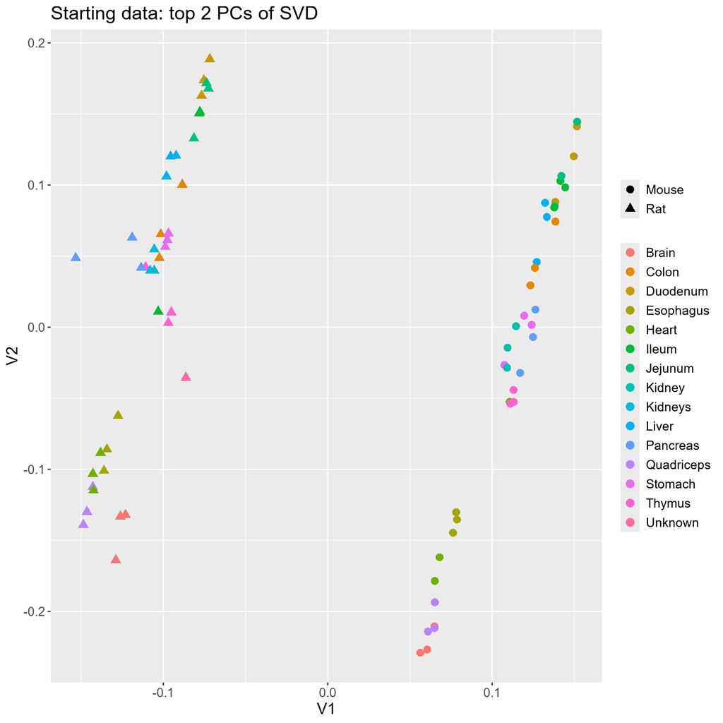

```r
#SVD plots
prior_svd = svd(t(scale(t(prior), scale=FALSE, center=TRUE)))
prior_svd = as.data.frame(prior_svd$v)
prior_svd = cbind(prior_svd, metadata)

after_svd = svd(t(scale(t(after), scale=FALSE, center=TRUE)))
after_svd = as.data.frame(after_svd$v)
after_svd = cbind(after_svd, metadata)

ggplot(prior_svd) +
    geom_point(aes(x=V1, y=V2, shape=species, col=tissue), size=3) +
    labs(title="Starting data: top 2 PCs of SVD") +
    theme(legend.title=element_blank(),
          text=element_text(size=14))
```

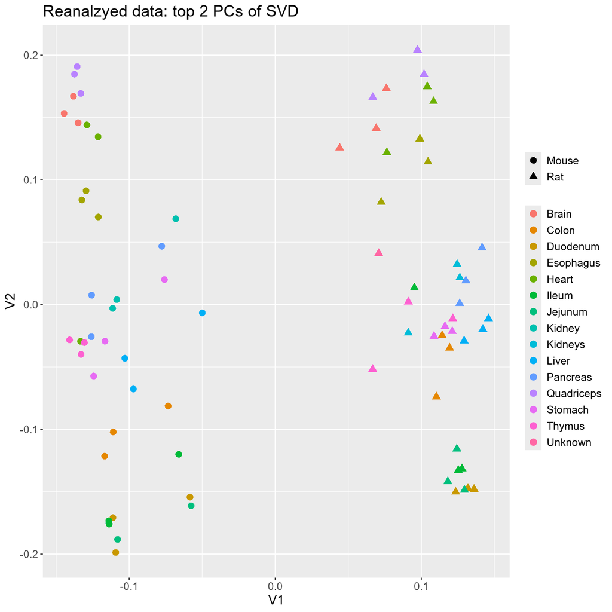

```r
ggplot(after_svd) +
    geom_point(aes(x=V1, y=V2, shape=species, col=tissue), size=3) +
    labs(title="Reanalzyed data: top 2 PCs of SVD") +
    theme(legend.title=element_blank(),
          text=element_text(size=14))
```

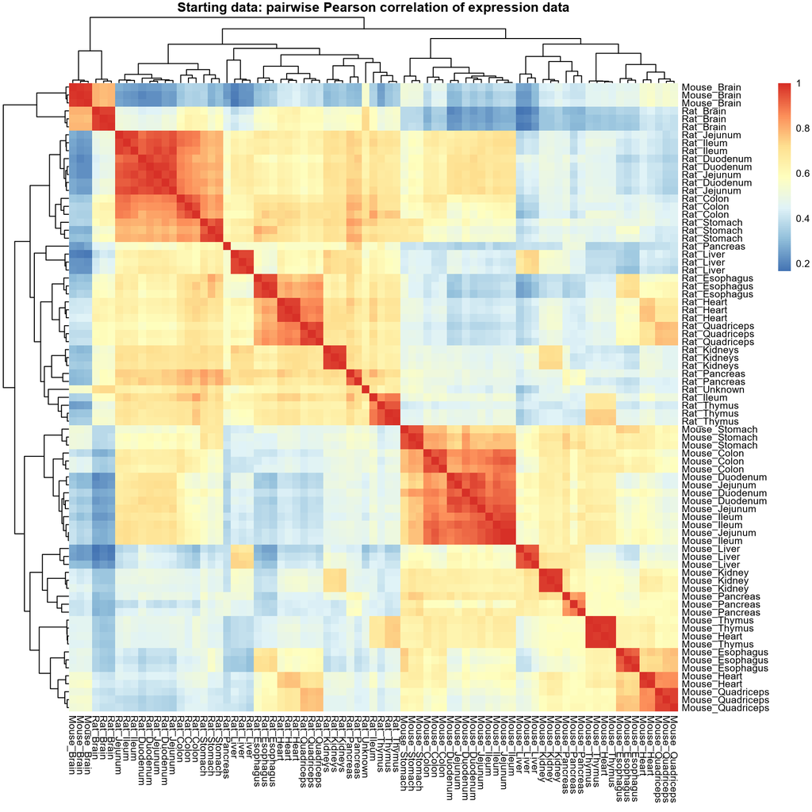

```r
#Heatmaps
pheatmap(cor(prior),
         border_color = NA,
         fontsize=8,
         main="Starting data: pairwise Pearson correlation of expression data")
```

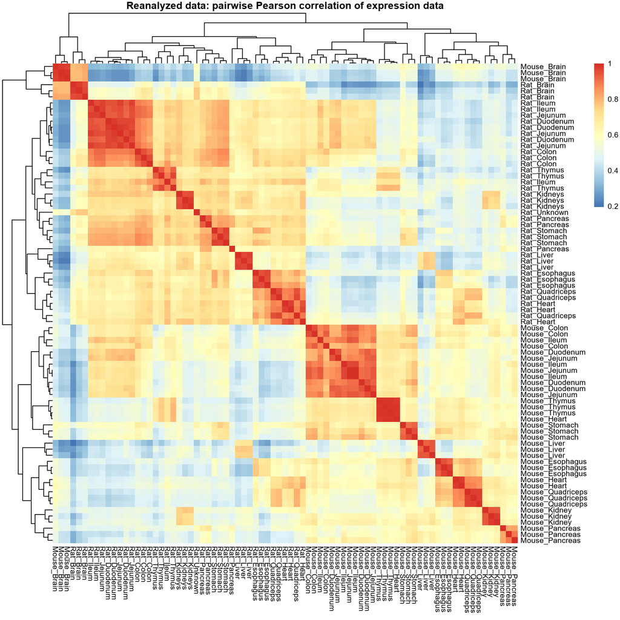

```r
pheatmap(cor(after),
         border_color = NA,
         fontsize=8,
         main="Reanalyzed data: pairwise Pearson correlation of expression data")
```